# Suicide Rates Overview 1985-2016

Khalil Hijazi

5/21/2019

## Introduction

How commmon is suicide nowadays in comparison to a few decades ago? Which age and gender groups is suicide more prevalent? What factors prove to be leading causes of suicide? More importantly, how can we use this information to better prevent this problem? Using this [Kaggle Dataset](https://www.kaggle.com/russellyates88/suicide-rates-overview-1985-to-2016) as well as general principles of data science, we can appropriately address these questions and many more. First, I will demonstrate how to collect the data and put it into a machine-readable form. Next, I will show you how to process the data and do some exploratory analysis and visualization in order to come up with hypotheses about the data. Finally, I will show you how to test these hypotheses using machine learning.

## Required Tools

I will be using R 3.6.0 to carry out this analysis. Aside from that, here is a list of the libraries I’ll be using:

- [tidyverse](https://www.tidyverse.org/)
- [magrittr](https://magrittr.tidyverse.org/)
- [ggplot2](https://ggplot2.tidyverse.org/)
- [broom](https://cran.r-project.org/web/packages/broom/index.html)

Lastly, if you plan on following this guide, you will need to download the [Kaggle Dataset](https://www.kaggle.com/russellyates88/suicide-rates-overview-1985-to-2016). **Note:** If you do not already have a Kaggle account, you will be required to create one to receive permission to download the dataset.

## 1. Getting Started

Let’s first start by downloading the data. I downloaded the data as a CSV (comma separated values) file and stored it under the **data** subdirectory.

Now, I will load the CSV file into a form that I can manipulate using R. To do so, I will use the **read_csv** function from the **tidyverse** package. It’s important to note that R uses rectangular grid data structures for storing data called data frames. In a data frame, each row corresponds to an entity and each of the columns is an attribute for the entities across the table. That being said, the *read_csv* function takes the dataset CSV file and loads it into a data frame, which we can then easily work with in R. For more information on the **tidyverse** package and its features, feel free to check out this [resource](https://www.tidyverse.org/).

```r
library(tidyverse)
# loading data into data frame
file_path <- "data/master.csv"
suicide_data <- read_csv(file_path)
# printing first ten rows of data frame
suicide_data %>% slice(1:10)
```

```
## # A tibble: 10 x 12
##    country  year sex   age   suicides_no population `suicides/100k …
##    <chr>   <dbl> <chr> <chr>       <dbl>      <dbl>            <dbl>
##  1 Albania  1987 male  15-2…          21     312900             6.71
##  2 Albania  1987 male  35-5…          16     308000             5.19
##  3 Albania  1987 fema… 15-2…          14     289700             4.83
##  4 Albania  1987 male  75+ …           1      21800             4.59
##  5 Albania  1987 male  25-3…           9     274300             3.28
##  6 Albania  1987 fema… 75+ …           1      35600             2.81
##  7 Albania  1987 fema… 35-5…           6     278800             2.15
##  8 Albania  1987 fema… 25-3…           4     257200             1.56
##  9 Albania  1987 male  55-7…           1     137500             0.73
## 10 Albania  1987 fema… 5-14…           0     311000             0
## # … with 5 more variables: `country-year` <chr>, `HDI for year` <dbl>,
## #   `gdp_for_year ($)` <dbl>, `gdp_per_capita ($)` <dbl>, generation <chr>
```

### 1.1 Observing the Data

We now have a data frame called **suicide_data** that has all our data. Here, we can see the basic attributes our entities will share such as country, year, sex, age, and other factors related to each suicide instance. Any missing data is assigned a value of NA.

One last thing to note is that attributes can come in a variety of data types, but there are five main types (categorical, numeric, datetime, geolocation, and other). An attribute can only belong to one type (i.e. if it is categorical, it cannot be numeric unless represented otherwise). If it is a categorical attribute, then it must be either ordered or unordered. Categorically ordered attributes are ones that contain a fixed set of values that have some importance paradigm. Categorically unordered attributes on the other hand are the exact opposite in the sense that there is no significance to the values other than the fact that they are different values. Similarly, if an attribute is numerical, it can either be discrete or continuous. I won’t go into depth of how this conclusion is arrived at but the general rule of thumb is that discrete numerical attributes are typically countable whereas continuous aren’t.

Here are some examples from our dataset:

- ‘country’ | categorical unordered | Takes a value from a finite set of countries |
- ‘suicides_no’ | numeric discrete | Takes a value from a finite set of numeric integer suicide counts |
- ‘suicides/100k pop’ | numeric continuous | Takes a value from an infinite set of ratios of suicides to 100k populations |

### 1.2 Tidying the Data

Taking a look at the data, some modifications are needed for the purpose of our operations on that data. For instance, certain columns aren’t necessary and can be deleted and more importantly, some attributes’ datatypes need to be changed to other datatypes that are more suitable to the computations they’ll be involved in.

I’ll first start by removing the unnecessary columns. I’ll be removing the ‘country-year’ attribute because that is simply a concatenation of the first two attributes and thus isn’t necessary. I’ll also be removing the ‘HDI for year’ attribute because there’s just not much data on it. Lastly, I’ll remove the ‘generation’ attribute because it is simply an encoding of the ‘age’ attribute, and thus we only need one of the two.

```r
drops <- c("country-year", "HDI for year", "generation") # attributes to be dropped
suicide_data[drops] <- NULL # dropping the collection of attributes from suicide_data data frame
suicide_data
```

```
# A tibble: 27,820 x 9
   country  year sex   age   suicides_no population `suicides/100k …
   <chr>   <dbl> <chr> <chr>       <dbl>      <dbl>            <dbl>
 1 Albania  1987 male  15-2…          21     312900             6.71
 2 Albania  1987 male  35-5…          16     308000             5.19
 3 Albania  1987 fema… 15-2…          14     289700             4.83
 4 Albania  1987 male  75+ …           1      21800             4.59
 5 Albania  1987 male  25-3…           9     274300             3.28
 6 Albania  1987 fema… 75+ …           1      35600             2.81
 7 Albania  1987 fema… 35-5…           6     278800             2.15
 8 Albania  1987 fema… 25-3…           4     257200             1.56
 9 Albania  1987 male  55-7…           1     137500             0.73
10 Albania  1987 fema… 5-14…           0     311000             0
# … with 27,810 more rows, and 2 more variables: `gdp_for_year ($)` <dbl>,
#   `gdp_per_capita ($)` <dbl>
```

Now that I’ve removed the unnecesssary columns, it’s time to modify certain datatypes to our advantage. First, I’ll change the ‘year’, ‘suicides_no’, ‘population’, and ‘gdp_per_capita ($)’ attributes to integer columns instead of doubles. Although, the attribute ‘gdp_for_year ($)’ is not a fractional number, I will leave it as a double because some of its entries are far too large to be represented as integer values in R.

**Note:** Here, I make use of the [magrittr](https://magrittr.tidyverse.org/) package. This package allows me to use the **%<>%** operation which is similar to the **%>%** dplyr operation, except that this one reassigns the data frame to whatever is resulted of the pipeline operations. So in this case, suicide_data is being modified once the columns have been mutated from doubles to integers.s

```r
library(magrittr)
int_cols <- c('year', 'suicides_no', 'population', 'gdp_per_capita ($)') # attributes to convert to integers

suicide_data[int_cols] %<>%
  mutate_all(as.integer) # modifying all the selected columns in int_cols from double datatype to integer

suicide_data
```

```
## # A tibble: 27,820 x 9
##    country  year sex   age   suicides_no population `suicides/100k …
##    <chr>   <int> <chr> <chr>       <int>      <int>            <dbl>
##  1 Albania  1987 male  15-2…          21     312900             6.71
##  2 Albania  1987 male  35-5…          16     308000             5.19
##  3 Albania  1987 fema… 15-2…          14     289700             4.83
##  4 Albania  1987 male  75+ …           1      21800             4.59
##  5 Albania  1987 male  25-3…           9     274300             3.28
##  6 Albania  1987 fema… 75+ …           1      35600             2.81
##  7 Albania  1987 fema… 35-5…           6     278800             2.15
##  8 Albania  1987 fema… 25-3…           4     257200             1.56
##  9 Albania  1987 male  55-7…           1     137500             0.73
## 10 Albania  1987 fema… 5-14…           0     311000             0
## # … with 27,810 more rows, and 2 more variables: `gdp_for_year ($)` <dbl>,
## #   `gdp_per_capita ($)` <int>
```

There are other methods of tidying data, such as uniting columns into one column or separating columns into multiple columns (we could’ve done this with the country-year column but it was easier to remove it since we already had two separate columns for country and year). Just because these methods weren’t used, that doesn’t mean they aren’t important; it just means that they weren’t needed for this dataset. As a data scientist, it is up to you to decide when certain methods are necessary and when not.

## 2. Exploratory Data Analysis

Now that we’ve tidyed up the data frame, we can start performing a variety of analyses on it. The goal of these analyses is to learn more about our data and possible notice some trends or patterns in the data and thereby be able to confidently make testable hypotheses. We will perform these analyses:

- Visualizations
- Statistical Measurements

To make some of these analyses possible, we will be using the library [ggplot2](https://ggplot2.tidyverse.org/) which enables us to make interactive plots for the purpose of visualizing trends across various attributes. There are multiple plots and graphs offered by this library such as scatter plots, violin plots, histograms, bar graphs, and so on and so forth. In case you wanted to learn more about each of these, this [cheat sheet](https://www.rstudio.com/wp-content/uploads/2015/03/ggplot2-cheatsheet.pdf) is worth looking at.

### 2.1 Suicide Count Across Time

#### 2.1.1 Visualization

We have a variety of groups in our data frame and we would like to see if there are some trends among those groups. That is, we would like to see whether or not a certain group (i.e. year, country, sex, age, etc.) has some overall effect on suicide count. Since our data is laid out in the form of suicide overviews per individual country at a certain year, we will need to group by certain attributes to make this trend measurement possible. We’ll first take a look at the general trend across time only.

Here, we will group by the year. That way, we will create a group for each year in our data frame. In each of those groups, we will have all the records of suicide counts in that year, regardless of other factors such as age, sex, and country.

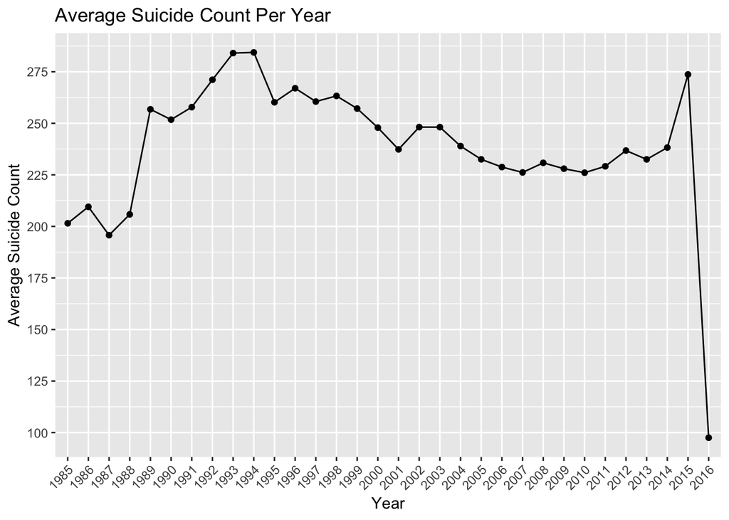

```r
library(ggplot2)

suicide_data %>%
  group_by(year) %>% # grouping by each year
  summarize(mean_suicide_count = mean(suicides_no)) %>% # computing mean suicide incidents per year
  ggplot(aes(x=factor(year), y=mean_suicide_count, group=1)) +
  geom_point() + # plotting points
  geom_line() + # plotting line across points
  scale_y_continuous(breaks = seq(0, 300, by = 25)) + # setting range for the mean suicide count values
  labs(title="Average Suicide Count Per Year", # decorating graph with axes titles as well as graph title
       x = "Year",
       y = "Average Suicide Count") +
  theme(axis.text.x = element_text(angle = 45, hjust = 1)) # formatting x axis labels by putting years at an angle
```

From this graph, we can tell that suicide count depends on the year attribute. Although this may seem obvious, it is good practice to often check for this type of information. We can also see that in earlier years of the data (i.e. 1985-1994), the average suicide count per year was increasing for the most part and in the later years (i.e. 1995 - 2014), the average suicide count per year decreased quite a bit. Unfortunately, it also spiked up quite a bit in 2015. Lastly, we can tell that the data for 2016 is either skewed due to very little information or we just did extremely well at lowering the average suicide count per year by approximately 175 incidents.

#### 2.1.2 Statistical Measurements

We can better affirm what we’ve observed by taking a look at some statistical measurements, specifically the mean and standard deviation, of the average suicide counts data we have across all the years.

```r
data_grouped_by_year <- suicide_data %>% group_by(year) %>% summarize(mean_suicide_count = mean(suicides_no))
mean(data_grouped_by_year$mean_suicide_count)
```

```
[1] 238.3583
```

```r
sd(data_grouped_by_year$mean_suicide_count)
```

```
[1] 34.12143
```

This seems reliable since the mean suicide count didn’t really jump or drop drastically very much across years. It was more of a slight alteration in value from year to year, and based on the fact that standard deviation gives us a measurement of spread, we can infer that suicide counts haven’t changed much from one year to another.

### 2.2 Suicide Count Per Sex Group Across Time

#### 2.2.1 Visualization

Similar to 2.1.1, we will first group by the year. However, now we are also subgrouping a second time based on sex affiliation. By doing so, we will have all the records of suicide counts for a given sex group for each year, regardless of other factors such as age, sex, and country.

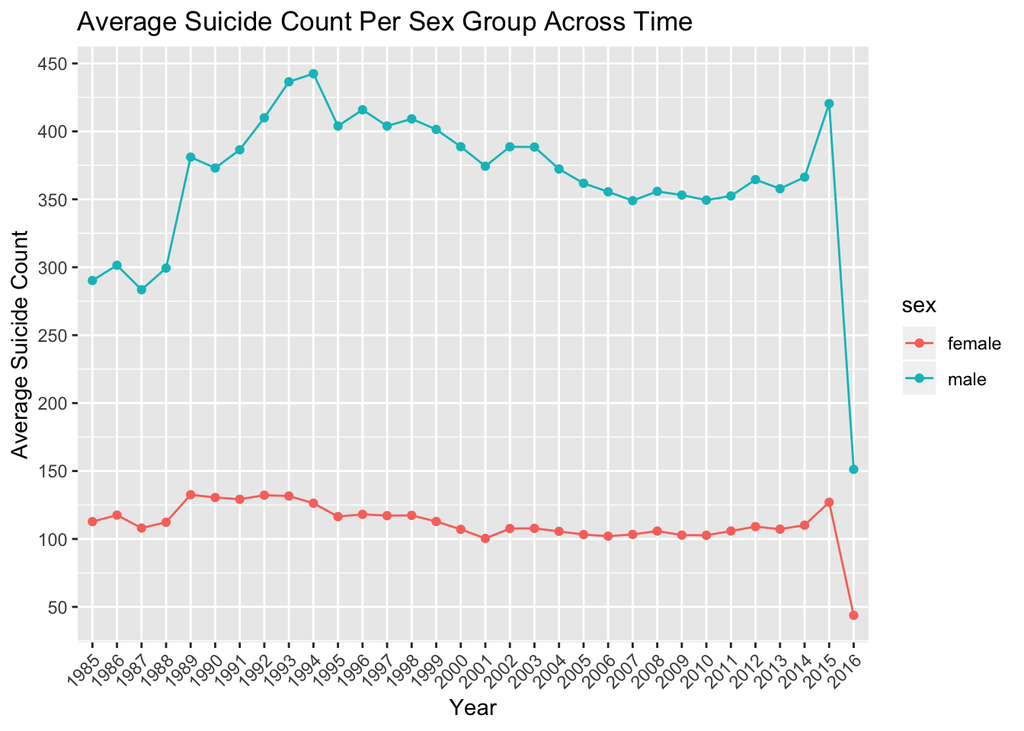

```r
suicide_data %>%
  group_by(year, sex) %>% # grouping by each year and then by sex
  summarize(mean_suicide_count = mean(suicides_no)) %>% # computing mean suicide incidents per year per sex group
  ggplot(aes(x=factor(year), y=mean_suicide_count, group=sex)) +
  geom_point(aes(color=sex)) + # plotting points
  geom_line(aes(color=sex)) + # plotting line across points
  scale_y_continuous(breaks = seq(0, 500, by = 50)) + # setting range for the mean suicide count values
  labs(title="Average Suicide Count Per Sex Group Across Time", # adding graph title plus axes titles
       x = "Year",
       y = "Average Suicide Count") +
  theme(axis.text.x = element_text(angle = 45, hjust = 1)) # formatting x axis labels by putting years at an angle
```

Based on this graph, we can tell for sure that males tend to have higher suicide incidents than do females. For each of the years (excluding 2016), there’s a huge difference in the average number of suicide incidents per each group, and this trend has been consistent over time, which makes it very likely to be true that suicide is generally more prevalent among males than females. We also now have confirmed that suicide counts are dependent on gender (i.e. they are not constant across gender groups).

#### 2.2.2 Statistical Measurements

We can better affirm what we’ve observed by taking a look at some statistical measurements, specifically the mean and standard deviation, of the average suicide counts data we have per sex group across all the years.

```r
data_grouped_by_sex <- suicide_data %>% group_by(year, sex) %>% summarize(mean_suicide_count = mean(suicides_no))
mean(data_grouped_by_sex$mean_suicide_count)
```

```
[1] 238.3583
```

```r
sd(data_grouped_by_sex$mean_suicide_count)
```

```
[1] 134.1331
```

These evaluations are understandable since the mean suicide count for each gender remained fairly consistent with respect to its gender, and thus most of the variation in this data is caused by the differences betweeen the average suicide count of each sex group across the years. Visually, one can notice this by observing the graph and noticing that there is a significant gap between each male and female data point for each year.

### 2.3 Suicide Count Per Country

#### 2.3.1 Visualization

Similar to section 2.2.1, here we will also group by the year first and then subgroup a second time based on country. We will do something differently however. Let’s first see how many possible values we have in the country attribute.

```r
categories <- unique(suicide_data$country)
categories
```

```
  [1] "Albania"                      "Antigua and Barbuda"
  [3] "Argentina"                    "Armenia"
  [5] "Aruba"                        "Australia"
  [7] "Austria"                      "Azerbaijan"
  [9] "Bahamas"                      "Bahrain"
 [11] "Barbados"                     "Belarus"
 [13] "Belgium"                      "Belize"
 [15] "Bosnia and Herzegovina"       "Brazil"
 [17] "Bulgaria"                     "Cabo Verde"
 [19] "Canada"                       "Chile"
 [21] "Colombia"                     "Costa Rica"
 [23] "Croatia"                      "Cuba"
 [25] "Cyprus"                       "Czech Republic"
 [27] "Denmark"                      "Dominica"
 [29] "Ecuador"                      "El Salvador"
```

[output cut: 36 more lines]

There are a lot of countries in this dataset (101 countries) and thus, we are required to break the plots into groups because placing all 101 countries in the same plot is nonsensical. As a matter of fact, the plot would break and one wouldn’t be able to make any meaning of the data. To alleviate this issue, I split the countries into five groups, each of size 20 except for the last which has size 21. Then, for each of these groups of countries, I filtered the data frame, then grouped by the year followed by country and plotted their respective plots. That’s why there are five plots as shown below.

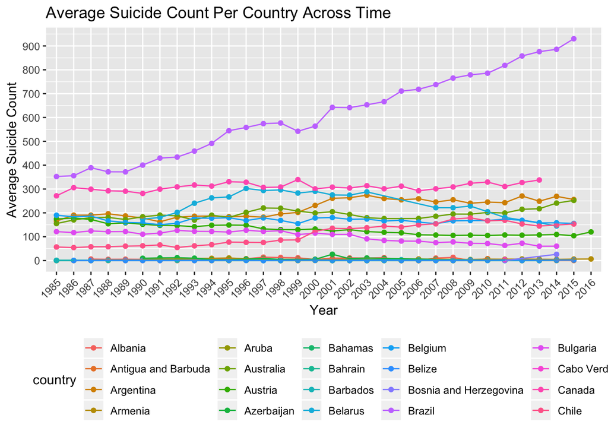

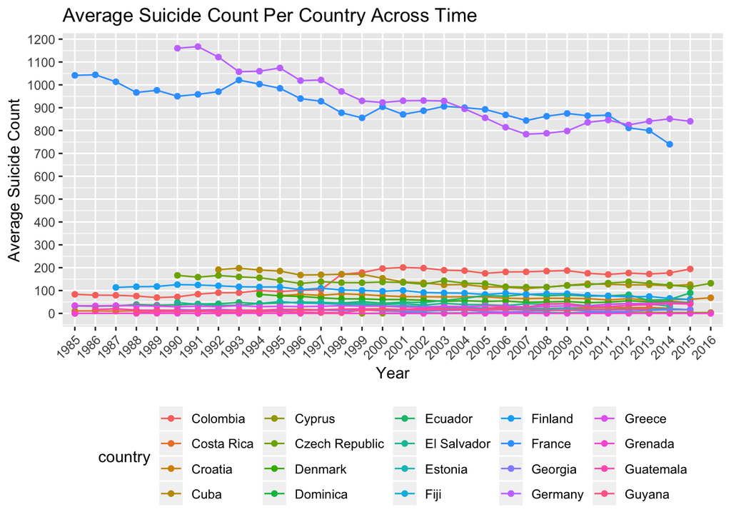

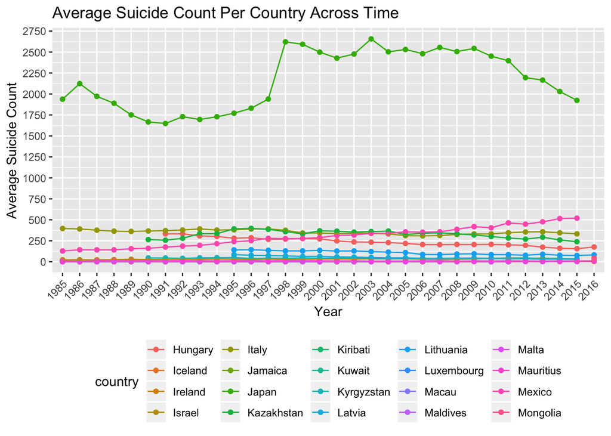

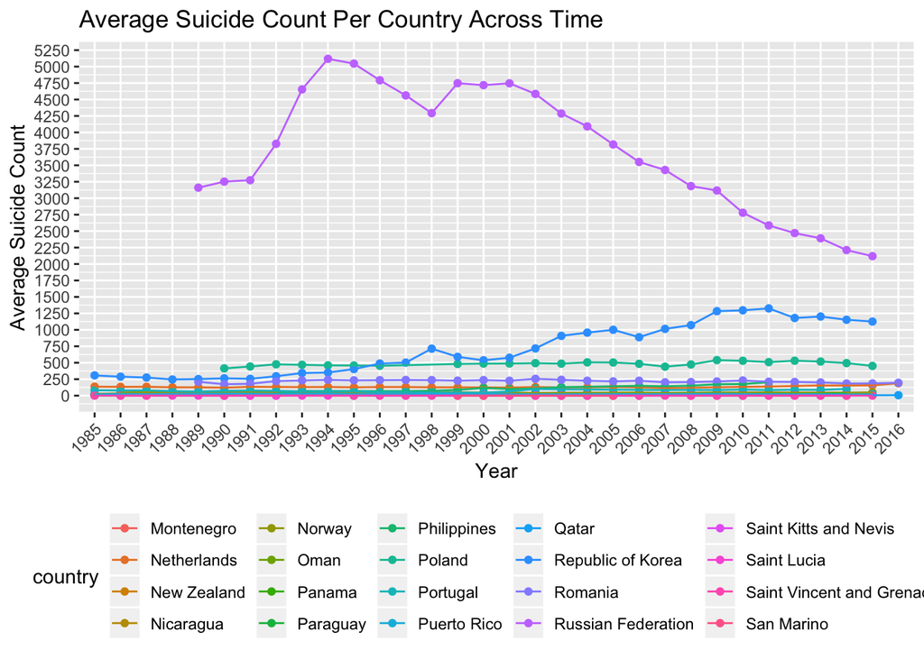

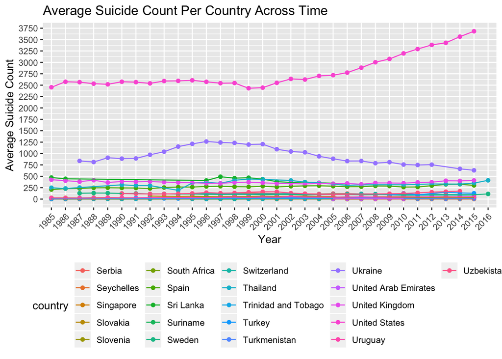

```r
for(i in seq(from=1, to=5, by=1)){
  sub_country_collection <- c() # group to hold 20 (21 if last group) countries
  for (j in seq(from=20 * (i - 1) + 1, to = 20 * i, by = 1)) {

    sub_country_collection <- c(sub_country_collection, categories[j]) # adding country[j] to subgroup
  }
  # checking if we're at the fifth group, then we need to add the 101th element to its
  if (i == 5) {
    sub_country_collection <- c(sub_country_collection, categories[101])
  }

  end_val <- 2000 # end value on y-axis
  increment <- 100 # increment value for y-axis

  # when i >= 3, we have high y-axiss values for some countries and thus need to bump up these parameters

  if (i >= 3) {
    end_val <- 6000
    increment <- 250
  }
  plt <- suicide_data %>%
    filter(country %in% sub_country_collection) %>% # selecting only countries in subgroup
    group_by(year, country) %>% # grouping by each year and then by country
    summarize(mean_suicide_count = mean(suicides_no)) %>% # computing mean suicide incidents per year per country
    ggplot(aes(x=factor(year), y=mean_suicide_count, group=country)) +
    geom_point(aes(color=country)) + # plotting points
    geom_line(aes(color=country)) + # plotting line across points
    # setting range for the mean suicide count values
    scale_y_continuous(breaks = seq(0, end_val, by = increment)) +
    labs(title="Average Suicide Count Per Country Across Time", # adding graph title plus axes titles
         x = "Year",
         y = "Average Suicide Count") +
    # formatting x axis labels by putting years at an angle
    # aligning the legend to under the graph
    theme(legend.position="bottom", axis.text.x = element_text(angle = 45, hjust = 1))
  print(plt)
}
```

From these plots, we can surely tell that that country specification has some degree of influence over the number of suicide incidents experienced. Some locations see more of it and others see less of it. It appears that most countries have been able to keep their average suicide count below 500 records. However, outliers certainly exist. For instance, the Russian Federation had average suicide counts more than 3000 until around 2010. Although, the nonoutlier countries are quite close to each other in lines, we need to note two things:

- the increment value on the y-axis isn’t the same across all graphs so not all countries (although they appear to fall in the same region across different graphs, that doesn’t necessarily mean they have relatively close values). That is to say, a country in the first plot and another country in the fourth plot could both be in the lower left region of their respected graphs but one could be pointing to a y-axis value of 100 suicide counts on average while the other could be pointing to a y-axis value of 400 suicide counds on average.
- similar to the above comment, the increments are pretty significant for some of the graphs. For instancee, on graphs 3-5, the increment is +250. That being said, two nearby points could have a difference of a hundred or so. Visually, the values appear to be close, but we need not to jump to conclusions too fast.

#### 2.3.2 Statistical Measurements

We can better affirm what we’ve observed by taking a look at some statistical measurements, specifically the mean and standard deviation, of the average suicide counts data we have per country across all the years.

```r
data_grouped_by_country <- suicide_data %>% group_by(year, country) %>% summarize(mean_suicide_count = mean(suicides_no))
mean(data_grouped_by_country$mean_suicide_count)
```

```
[1] 242.4077
```

```r
sd(data_grouped_by_country$mean_suicide_count)
```

```
[1] 589.81
```

## 3. Machine Learning

Machine learning is a broad field and describing it in just a few sentences isn’t exactly the easiest thing per se. However, if I had to put it into a few sentences, I’d say that machine learning is the art of teaching machines to replicate human intelligence in pattern recognition and prediction based on that recognition through the use sufficient data and well designed, strategic algorithms to operate on that data.

### 3.1 Fitting Mulitlinear Model

Based on the data explored earlier, it seems like multilinear regression would probably be our best bet at predicting suicide count if given informaation like the year, country, sex, and so on. We’ll first start by fitting the multiregression model and seeing which predictors are needed and which not.

#### 3.1.1 A Series of Likelihood Ratio Tests

First, I will build two models, one with the country attribute and the second without the country attribute since the country attribute is categorical. I will be performing a likelihood ratio test to determine the overall effect of the country attribute on the results. To perform this test, I will fit the two models as I described earlier, and use the anova function to produce the test results for me.

```r
library(broom)
data_fit <- lm(suicides_no~1+country+year+sex+age+population, data=suicide_data)
data_fit2 <- lm(suicides_no~1+year+sex+age+population, data=suicide_data)

anova(data_fit, data_fit2, test="LRT")
```

```
Analysis of Variance Table

Model 1: suicides_no ~ 1 + country + year + sex + age + population
Model 2: suicides_no ~ 1 + year + sex + age + population
  Res.Df        RSS   Df   Sum of Sq  Pr(>Chi)
1  27711 1.0113e+10
2  27811 1.3121e+10 -100 -3007117908 < 2.2e-16 ***
---
Signif. codes:  0 '***' 0.001 '**' 0.01 '*' 0.05 '.' 0.1 ' ' 1
```

Based on this result, the likelihood ratio test was highly significant, thereby allowing us to conclude that the variable country should remain in the model.

I will now repeat this process with the age and sex attributes.

```r
data_fit2 <- lm(suicides_no~1+country+year+age+population, data=suicide_data)
anova(data_fit, data_fit2, test="LRT")
```

```
Analysis of Variance Table

Model 1: suicides_no ~ 1 + country + year + sex + age + population
Model 2: suicides_no ~ 1 + country + year + age + population
  Res.Df        RSS Df  Sum of Sq  Pr(>Chi)
1  27711 1.0113e+10
2  27712 1.0640e+10 -1 -526315878 < 2.2e-16 ***
---
Signif. codes:  0 '***' 0.001 '**' 0.01 '*' 0.05 '.' 0.1 ' ' 1
```

Based on this result, the likelihood ratio test was highly significant, thereby allowing us to conclude that the sex attribute should remain in the model.

```r
data_fit2 <- lm(suicides_no~1+country+year+sex+population, data=suicide_data)
anova(data_fit, data_fit2, test="LRT")
```

```
Analysis of Variance Table

Model 1: suicides_no ~ 1 + country + year + sex + age + population
Model 2: suicides_no ~ 1 + country + year + sex + population
  Res.Df        RSS Df  Sum of Sq  Pr(>Chi)
1  27711 1.0113e+10
2  27716 1.0510e+10 -5 -396658415 < 2.2e-16 ***
---
Signif. codes:  0 '***' 0.001 '**' 0.01 '*' 0.05 '.' 0.1 ' ' 1
```

Based on this result, the likelihood ratio test was highly significant, thereby allowing us to conclude that the age attribute should remain in the model.

#### 3.1.2 Checking Necessity of Other Attributes

Now, let’s take a look at the rest of the attributes (i.e. the numeric ones) and see which ones we need to remove from our model.

```r
summary(data_fit)
```

```
Call:
lm(formula = suicides_no ~ 1 + country + year + sex + age + population,
    data = suicide_data)

Residuals:
    Min      1Q  Median      3Q     Max
-3980.4  -149.3     3.9   104.7 17127.7

Coefficients:
                                      Estimate Std. Error t value Pr(>|t|)
(Intercept)                          3.491e+03  8.943e+02   3.903 9.51e-05
countryAntigua and Barbuda           3.034e+01  5.009e+01   0.606 0.544757
countryArgentina                    -1.984e+02  4.892e+01  -4.055 5.03e-05
countryArmenia                       2.488e-01  5.108e+01   0.005 0.996114
countryAruba                         3.965e+01  5.967e+01   0.664 0.506394
countryAustralia                    -1.763e+01  4.903e+01  -0.360 0.719136
countryAustria                       5.941e+01  4.836e+01   1.228 0.219271
countryAzerbaijan                   -5.797e+01  5.731e+01  -1.011 0.311808
countryBahamas                       3.159e+01  5.202e+01   0.607 0.543678
countryBahrain                       2.856e+01  5.323e+01   0.537 0.591543
countryBarbados                      2.808e+01  5.098e+01   0.551 0.581789
countryBelarus                       1.450e+02  5.322e+01   2.724 0.006462
countryBelgium                       6.875e+01  4.863e+01   1.414 0.157472
countryBelize                        3.260e+01  4.970e+01   0.656 0.511849
countryBosnia and Herzegovina        1.932e+01  1.289e+02   0.150 0.880868
countryBrazil                       -1.476e+03  5.591e+01 -26.396  < 2e-16
countryBulgaria                      2.792e+01  4.896e+01   0.570 0.568448
countryCabo Verde                    5.018e+01  1.784e+02   0.281 0.778496
countryCanada                       -4.548e+01  4.952e+01  -0.918 0.358412
countryChile                        -4.423e+01  4.866e+01  -0.909 0.363340
countryColombia                     -3.081e+02  4.897e+01  -6.291 3.21e-10
countryCosta Rica                    4.170e+00  4.895e+01   0.085 0.932106
countryCroatia                       5.420e+01  5.275e+01   1.027 0.304217
countryCuba                          4.082e+01  5.152e+01   0.792 0.428213
countryCyprus                        3.734e+01  5.874e+01   0.636 0.524958
countryCzech Republic                3.896e+01  5.020e+01   0.776 0.437730
countryDenmark                       2.969e+01  5.263e+01   0.564 0.572697
countryDominica                      3.384e+00  1.784e+02   0.019 0.984870
countryEcuador                      -6.231e+01  4.864e+01  -1.281 0.200177
countryEl Salvador                   6.974e+00  5.149e+01   0.135 0.892267
```

[output cut: 180 more lines]

```
countryUzbekistan                   *
year                                ***
sexmale                             ***
age25-34 years                      ***
age35-54 years                      ***
age5-14 years                       ***
age55-74 years                      ***
age75+ years                        ***
population                          ***
---
Signif. codes:  0 '***' 0.001 '**' 0.01 '*' 0.05 '.' 0.1 ' ' 1

Residual standard error: 604.1 on 27711 degrees of freedom
Multiple R-squared:  0.5532,    Adjusted R-squared:  0.5515
F-statistic: 317.7 on 108 and 27711 DF,  p-value: < 2.2e-16
```

Here is a tidyed up version

```r
data_fit_stats <- data_fit %>%
  tidy()
data_fit_stats %>% knitr::kable()
```

| term | estimate | std.error | statistic | p.value |
| --- | --- | --- | --- | --- |
| (Intercept) | 3490.7007228 | 894.2763596 | 3.9033803 | 0.0000951 |
| countryAntigua and Barbuda | 30.3373681 | 50.0912045 | 0.6056426 | 0.5447571 |
| countryArgentina | -198.3679916 | 48.9234592 | -4.0546600 | 0.0000503 |
| countryArmenia | 0.2488175 | 51.0849254 | 0.0048707 | 0.9961138 |
| countryAruba | 39.6482206 | 59.6688057 | 0.6644715 | 0.5063941 |
| countryAustralia | -17.6310383 | 49.0272279 | -0.3596173 | 0.7191361 |
| countryAustria | 59.4114630 | 48.3610714 | 1.2284977 | 0.2192706 |
| countryAzerbaijan | -57.9664460 | 57.3100100 | -1.0114541 | 0.3118080 |
| countryBahamas | 31.5902123 | 52.0201850 | 0.6072684 | 0.5436778 |
| countryBahrain | 28.5638903 | 53.2305415 | 0.5366072 | 0.5915433 |
| countryBarbados | 28.0799875 | 50.9822626 | 0.5507795 | 0.5817892 |
| countryBelarus | 144.9546409 | 53.2223919 | 2.7235649 | 0.0064622 |
| countryBelgium | 68.7499511 | 48.6325261 | 1.4136619 | 0.1574724 |
| countryBelize | 32.5993780 | 49.6964575 | 0.6559699 | 0.5118490 |
| countryBosnia and Herzegovina | 19.3235572 | 128.9351278 | 0.1498704 | 0.8808680 |
| countryBrazil | -1475.6472493 | 55.9052089 | -26.3955234 | 0.0000000 |
| countryBulgaria | 27.9235575 | 48.9590598 | 0.5703451 | 0.5684483 |
| countryCabo Verde | 50.1789792 | 178.3934123 | 0.2812827 | 0.7784957 |
| countryCanada | -45.4821341 | 49.5226541 | -0.9184107 | 0.3584119 |
| countryChile | -44.2299214 | 48.6559278 | -0.9090346 | 0.3633398 |
| countryColombia | -308.0692002 | 48.9717890 | -6.2907483 | 0.0000000 |
| countryCosta Rica | 4.1704477 | 48.9514207 | 0.0851956 | 0.9321065 |
| countryCroatia | 54.2026609 | 52.7544378 | 1.0274522 | 0.3042166 |
| countryCuba | 40.8210518 | 51.5244658 | 0.7922654 | 0.4282127 |
| countryCyprus | 37.3429074 | 58.7402364 | 0.6357296 | 0.5249579 |
| countryCzech Republic | 38.9557244 | 50.1978504 | 0.7760437 | 0.4377298 |
| countryDenmark | 29.6908291 | 52.6348560 | 0.5640906 | 0.5726970 |
| countryDominica | 3.3836195 | 178.4268196 | 0.0189636 | 0.9848703 |
| countryEcuador | -62.3104237 | 48.6390704 | -1.2810776 | 0.2001771 |
| countryEl Salvador | 6.9742677 | 51.4944117 | 0.1354374 | 0.8922671 |

[output cut: 79 more lines]

Based on this, we can see that the year attribute has a p-value = 0.0000299 <= 0.05. The population attribute also has a p-value = 0.0000000 <= 0.05. Therefore, we need to include these in our model.

Since all the attributes we chose at first were correct, we need not change our model and can proceed to checking other methods of verifying our linear model relationship.

### 3.2 Checking for Non-linearity of outcome-predictor relationship

```r
augmented_data <- data_fit %>%
  augment()
augmented_data %>% head()
```

```
# A tibble: 6 x 13
  suicides_no country  year sex   age   population .fitted .se.fit .resid
        <int> <chr>   <int> <chr> <chr>      <int>   <dbl>   <dbl>  <dbl>
1          21 Albania  1987 male  15-2…     312900   109.     38.6  -88.4
2          16 Albania  1987 male  35-5…     308000   262.     38.7 -246.
3          14 Albania  1987 fema… 15-2…     289700  -170.     38.6  184.
4           1 Albania  1987 male  75+ …      21800   238.     38.7 -237.
5           9 Albania  1987 male  25-3…     274300   178.     38.6 -169.
6           1 Albania  1987 fema… 75+ …      35600   -35.3    38.7   36.3
# … with 4 more variables: .hat <dbl>, .sigma <dbl>, .cooksd <dbl>,
#   .std.resid <dbl>
```

With that we can make the plot we need to check for possible non-linearity

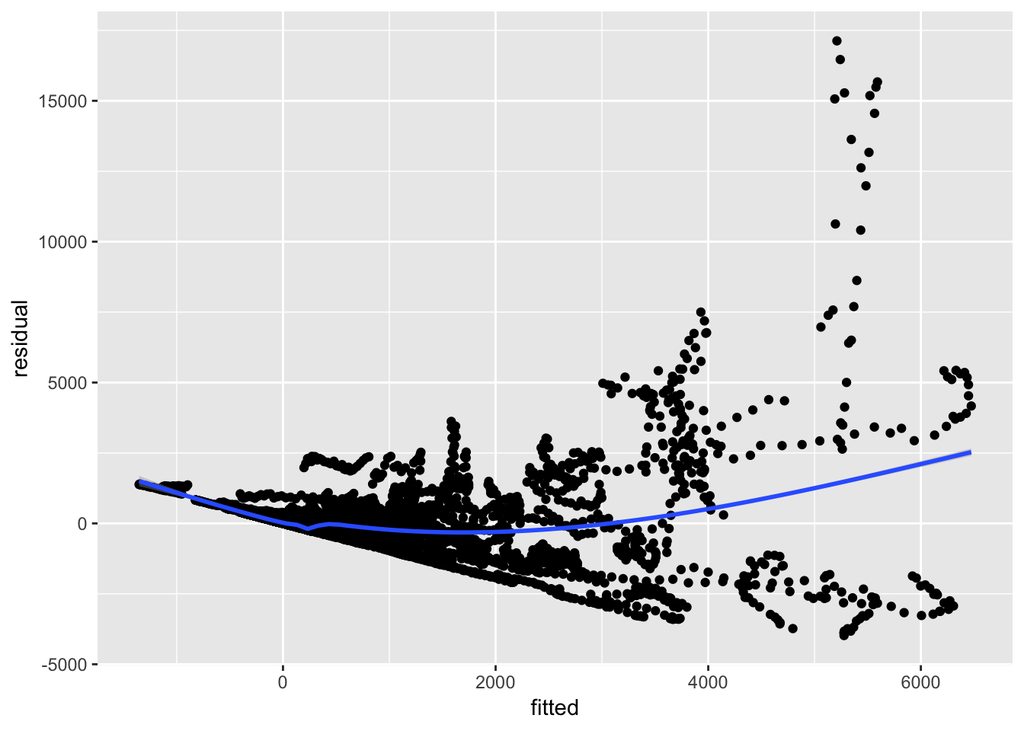

```r
augmented_data %>%
  ggplot(aes(x=.fitted,y=.resid)) +
    geom_point() +
    geom_smooth() +
    labs(x="fitted", y="residual")
```

### 3.3 Making Predictions on Validation Set

We can now test our model by letting it run predictions on a validation set and see what results are revealed.

```r
set.seed(1234)

in_validation <- sample(nrow(suicide_data), nrow(suicide_data)/2)
validation_set <- suicide_data[in_validation,]
training_set <- suicide_data[-in_validation,]
test_data_model <- lm(suicides_no~1+country+year+sex+age+population, data=training_set)
pred <- predict.lm(test_data_model, validation_set)
actuals_preds <- data.frame(cbind(actuals=training_set$suicides_no, predicteds=pred))
correlation_accuracy <- cor(actuals_preds)
correlation_accuracy
```

```
               actuals  predicteds
actuals    1.000000000 0.006824043
predicteds 0.006824043 1.000000000
```

```r
head(actuals_preds)
```

```
  actuals  predicteds
1      16 -155.496660
2      14   49.861816
3       1  217.729920
4       9    7.438579
5       4  -37.157129
6       1 1228.222227
```

Here, I also compute the Min Max Accuracy as well as the Mean Absolute Percentage Error (MAPE)

```r
min_max_acc <- mean(apply(actuals_preds, 1, min) / apply(actuals_preds, 1, max))
min_max_acc
```

```
[1] -Inf
```

```r
mape <- mean(abs((actuals_preds$predicteds - actuals_preds$actuals))/actuals_preds$actuals)
mape
```

```
[1] Inf
```